# SME0809 - Inferência Bayesiana

#### Nome: Juan Lucas Montanaro

## Exercício Distribuição de Poisson - Resposta

Considerando-se $Y_1, Y_2, ..., Y_n$ uma a.a. de $Y$ ∼ $Poisson(\theta)$ pede-se:

### a) Encontre a distribuição *a priori* não informativa de Jeffreys.

Pelo enunciado, têm-se que: $f_Y(y) = \frac{e^{-\theta}\theta^y}{y!}$; Assim:
$$\log{f_Y(y)} = -\theta +
y\log{\theta}-\log{y!};$$
$$\frac{d}{d\theta}\log{f_Y(y)} = -1 +
\frac{y}{\theta};$$
$$\frac{d^2}{d\theta^2}\log{f_Y(y)} =
-\frac{y}{\theta^2};$$
Logo, a informação de Fisher de $Y$, $J(\theta)$, é:
$$J(\theta) = -E\Big(
\frac{d^2}{d\theta^2}\log{f_Y(y)} \Big) = \frac{E(Y)}{\theta^2} =
\frac{\theta}{\theta^2} = \frac{1}{\theta}.$$
Portanto, como $\pi(\theta) \propto J(\theta)^{1/2}$, então a distribuição *a priori* não informativa de Jeffreyes é $\pi(\theta) \propto \sqrt{\frac{1}{\theta}}$.

### b) A função de verossimilhança na parametrização θ muda em locação e escala?

Primeiramente, a função de verossimilhança de $Y$ com $\theta$ desconhecido é:
$$L(\theta) = \prod^n_{i=1} \frac{e^{-\theta}
\theta^{y_i}}{y_i!} \propto e^{-n\theta} \theta^{n
\overline{y}}$$
Veja que então a verossimilhança tem distribuição $Gama(n\overline{y}+1, n)$; dessa forma, para diferentes valores de $\theta$, obtém-se os seguintes gráficos:

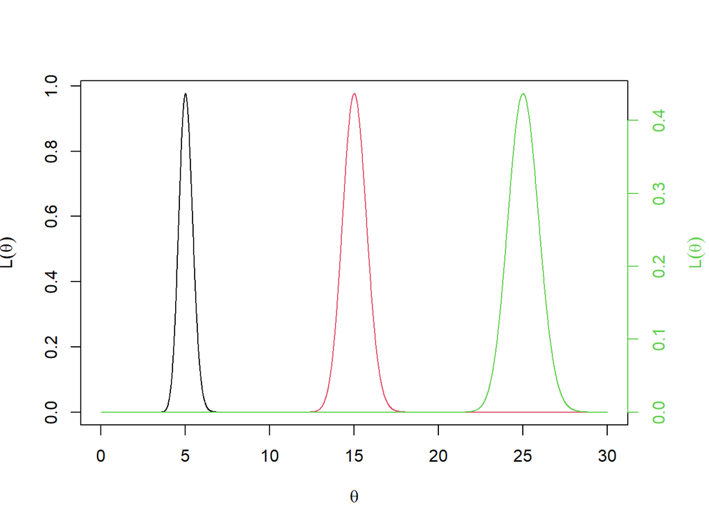

```r
t <- seq(0, 30, 0.01) #theta
n <- 30
yb <- c(5, 15, 25) #y barra

# Gráficos:
par(mar= c(4,4,4,4))

plot(t, dgamma(t, n*yb[1]+1, n),
     ylab=expression(L(theta)),
     xlab=expression(theta),
     type= "l")

par(new=T)
plot(t, dgamma(t, n*yb[2]+1, n),
     type= "l", axes=F,
     frame=T, ann=F, col=2)

par(new=T)
plot(t, dgamma(t, n*yb[3]+1, n),
     type= "l", axes= F,
     frame=T, ann=F, col=3)

axis(4, col.axis=3, col=3)
mtext(expression(L(theta)),
      side=4, line=3, col=3)
```

Portanto, de acordo com o gráfico, na parametrização $\theta$ a função de verossimilhança muda em locação e em escala.

### c) Caso a resposta do item b) seja afirmativa, encontre a escala na qual a função de verosimilhança mude somente em locação.

Como visto em aula, para encontrar a escala em que a função de verossimilhança muda apenas em locação precisamos da integral da distribuição *a priori*. Então seja $\phi$ a nova escala; assim:

$$\phi = \int\pi(\theta)d\theta \propto
\int\sqrt{\frac{1}{\theta}}d\theta \propto \sqrt{\theta}$$

E, para encontrar a distribuição de $\phi$:

$$F_\phi(p) = P(\phi<p) =
P(\sqrt{\theta}<p) = P(\theta<p^2) = F_\theta(p^2);$$
Em que $p>0$, $F_\phi(p)$ é a função densidade acumulada de $\phi$ no ponto $p$ e $F_\theta(p^2)$ é a função densidade acumulada de $\theta$ no ponto $p^2$; logo:

$$\frac{d}{dp}F_\phi(p) = f_\phi(p) =
\frac{d}{dp}F_\theta(p^2) = f_\theta(p^2)2p.$$

Portanto, $f_\phi(p)=f_\theta(p^2)2p$ é a função de distribuiçaõ de $\phi = \sqrt{\theta}$ e, nesta escala, a função de verossimilhança muda apenas em locação. Confira o gráfico comparativo:

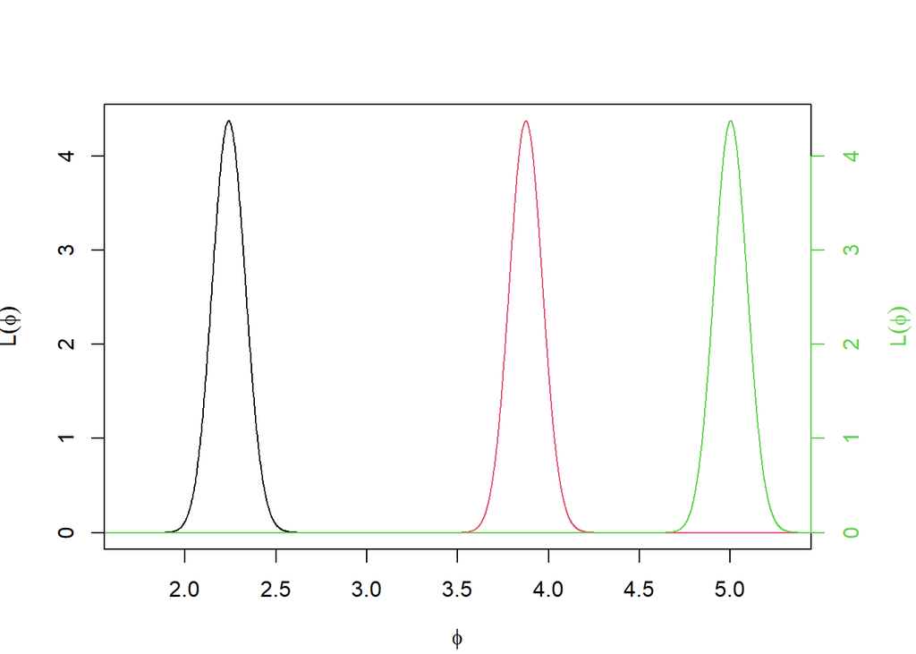

```r
# Gráficos:
p <- sqrt(t) #phi

par(mar = c(4,4,4,4))

plot(p, dgamma(p^2, n*yb[1]+1, n)*2*p,
     ylab=expression(L(phi)),
     xlab=expression(phi),
     xlim=c(1.7,5.3), type= "l")

par(new=T)
plot(p, dgamma(p^2, n*yb[2]+1, n)*2*p,
     type= "l", axes=F, xlim=c(1.7,5.3),
     frame=T, ann=F, col=2)

par(new=T)
plot(p, dgamma(p^2, n*yb[3]+1, n)*2*p,
     type= "l", axes= F, xlim=c(1.7,5.3),
     frame=T, ann=F, col=3)

axis(4, col.axis=3, col=3)
mtext(expression(L(phi)),
      side=4, line=3, col=3)
```